# MThambeliyagodage_Data605_W12_Assign12

Matheesha Thambeliyagodage

April 28, 2018

```r
library(ggplot2)
library(dplyr)
# library(gridExtra)
```

# Data 605 Assignment 12

### Data Import

```r
# Import data
who <- read.csv('https://raw.githubusercontent.com/mathsanu/CUNY_MSDA/master/DATA605/W12/who.csv')

knitr::kable(head(who[,c(1,2,6,8,9,10)]))
```

[output not shown]

Data is real-world World Health Organization data from 2008. It includes 190 observations for 10 variables. Data dictionary:

- `Country`: name of the country
- `LifeExp`: average life expectancy for the country in years
- `InfantSurvival`: proportion of those surviving to one year or more
- `Under5Survival`: proportion of those surviving to five years or more
- `TBFree`: proportion of the population without TB
- `PropMD`: proportion of the population who are MDs
- `PropRN`: proportion of the population who are RNs
- `PersExp`: mean personal expenditures on healthcare in US dollars at average exchange rate
- `GovtExp`: mean government expenditures per capita on healthcare, US dollars at average exchange rate
- `TotExp`: sum of personal and government expenditures

### Data Exploration

```r
summary(who)
```

```
                Country       LifeExp      InfantSurvival   Under5Survival       TBFree           PropMD
 Afghanistan        :  1   Min.   :40.00   Min.   :0.8350   Min.   :0.7310   Min.   :0.9870   Min.   :0.0000196
 Albania            :  1   1st Qu.:61.25   1st Qu.:0.9433   1st Qu.:0.9253   1st Qu.:0.9969   1st Qu.:0.0002444
 Algeria            :  1   Median :70.00   Median :0.9785   Median :0.9745   Median :0.9992   Median :0.0010474
 Andorra            :  1   Mean   :67.38   Mean   :0.9624   Mean   :0.9459   Mean   :0.9980   Mean   :0.0017954
 Angola             :  1   3rd Qu.:75.00   3rd Qu.:0.9910   3rd Qu.:0.9900   3rd Qu.:0.9998   3rd Qu.:0.0024584
 Antigua and Barbuda:  1   Max.   :83.00   Max.   :0.9980   Max.   :0.9970   Max.   :1.0000   Max.   :0.0351290
 (Other)            :184
     PropRN             PersExp           GovtExp             TotExp
 Min.   :0.0000883   Min.   :   3.00   Min.   :    10.0   Min.   :    13
 1st Qu.:0.0008455   1st Qu.:  36.25   1st Qu.:   559.5   1st Qu.:   584
 Median :0.0027584   Median : 199.50   Median :  5385.0   Median :  5541
 Mean   :0.0041336   Mean   : 742.00   Mean   : 40953.5   Mean   : 41696
 3rd Qu.:0.0057164   3rd Qu.: 515.25   3rd Qu.: 25680.2   3rd Qu.: 26331
 Max.   :0.0708387   Max.   :6350.00   Max.   :476420.0   Max.   :482750
```

### Question 1

Let us build a linear regression model for predicting life expectancy by total expenditures. Below scatterplot shows the relationship along with the linear regression line.

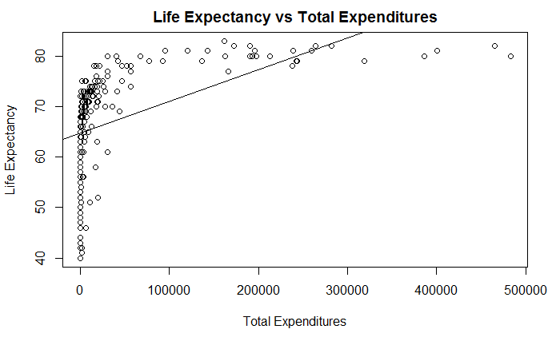

```r
# Linear regression model build
life_exp_lm <- lm(LifeExp ~ TotExp, data=who)
# Scatterplot of dependent and independent variables
plot(LifeExp~TotExp, data=who,
     xlab="Total Expenditures", ylab="Life Expectancy",
     main="Life Expectancy vs Total Expenditures")
abline(life_exp_lm)
```

```r
# Linear regression model summary
summary(life_exp_lm)
```

```
Call:
lm(formula = LifeExp ~ TotExp, data = who)

Residuals:
    Min      1Q  Median      3Q     Max
-24.764  -4.778   3.154   7.116  13.292

Coefficients:
                Estimate   Std. Error t value           Pr(>|t|)
(Intercept) 64.753374534  0.753536611  85.933            < 2e-16 ***
TotExp       0.000062970  0.000007795   8.079 0.0000000000000771 ***
---
Signif. codes:  0 ‘***’ 0.001 ‘**’ 0.01 ‘*’ 0.05 ‘.’ 0.1 ‘ ’ 1

Residual standard error: 9.371 on 188 degrees of freedom
Multiple R-squared:  0.2577,    Adjusted R-squared:  0.2537
F-statistic: 65.26 on 1 and 188 DF,  p-value: 0.00000000000007714
```

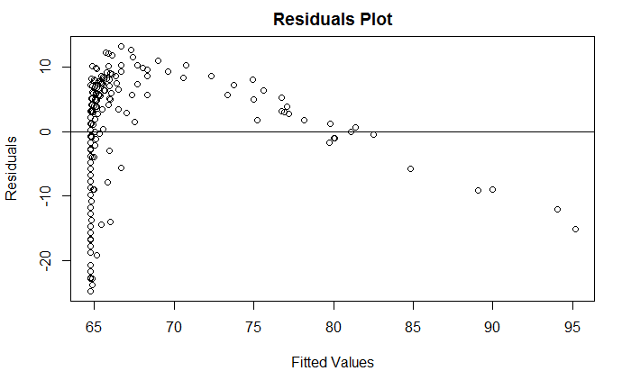

```r
# Residuals variability plot
plot(life_exp_lm$fitted.values, life_exp_lm$residuals,
     xlab="Fitted Values", ylab="Residuals",
     main="Residuals Plot")
abline(h=0)
```

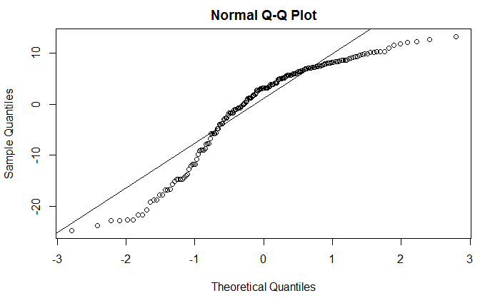

```r
# Residuals Q-Q plot
qqnorm(life_exp_lm$residuals)
qqline(life_exp_lm$residuals)
```

#### Results

**Residual standard error** is 9.371 and **F-statistic** is 65.26. Considering that average life expectancy is 67.38, the SE is not terrible and F-statistics is high. However, $R^2$ is only 0.2577 (so the model explains only 25.77% of variability). **P-value** is nearly 0, so the relationship is not due to random variation.

Looking at residuals plots it is clear that there is no constant variability and that residuals are not normally distributed. This is **not a good model** to describe the relationship. It is clear from the scatterplot that the relationship is not linear.

### Question 2

Let us transform variables and re-run the simple linear regression model - $LifeExp^{4.6}$ and $TotExp^{0.06}$.

```r
# Transformation
LifeExp4.6 <- who$LifeExp^4.6
TotExp0.06 <- who$TotExp^0.06

# Linear regression model build
life_exp_lm <- lm(LifeExp4.6 ~ TotExp0.06)

# Scatterplot of dependent and independent variables
plot(LifeExp4.6~TotExp0.06,
     xlab="Total Expenditures", ylab="Life Expectancy",
     main="Life Expectancy vs Total Expenditures (Transformed)")
abline(life_exp_lm)

# Linear regression model summary
summary(life_exp_lm)

# Residuals variability plot
plot(life_exp_lm$fitted.values, life_exp_lm$residuals,
     xlab="Fitted Values", ylab="Residuals",
     main="Residuals Plot")
abline(h=0)

# Residuals Q-Q plot
qqnorm(life_exp_lm$residuals)
qqline(life_exp_lm$residuals)
```

[output not shown]

#### Results

**Residual standard error** is 90,490,000 and **F-statistic** is 507.7. The F-statistic is good, but the SE is a bit high considering that it corresponds to 53.67 years if we reverse the transformation). $R^2$ is 0.7298, which is considerably better than in the first model (the model explains 72.98% of variability). **P-value** is again nearly 0, so the relationship is not due to random variation.

Looking at residuals plots, variability is fairly constant with a few outliers and distribution of residuals is nearly normal with some deviation at the tails. This is **a fairly good model** to describe the relationship and it is significantly better than the first model. The linear relationship between transformed variables is clear from the scatterplot.

### Question 3

```r
newdata <- data.frame(TotExp0.06=c(1.5,2.5))
predict(life_exp_lm, newdata,interval="predict")^(1/4.6)
```

```
       fit      lwr      upr
1 63.31153 35.93545 73.00793
2 86.50645 81.80643 90.43414
```

Based on the second model, prediction for total expeditures of $860.705 ($TotExp^{0.06}=1.5$) is 63.31 years with a 95% confidence interval between 35.94 and 73.01.

Prediction for total expeditures of $4,288,777 ($TotExp^{0.06}=2.5$) is 86.51 years with a 95% confidence interval between 81.81 and 90.43.

### Question 4

Let us build the following model: $LifeExp = \beta_0+\beta_1 \times PropMD + \beta_2 \times TotExp + \beta_3 \times PropMD \times TotExp$.

```r
# Multiple linear regression model build
life_exp_lm <- lm(LifeExp ~ PropMD + TotExp + TotExp:PropMD, data=who)

# Linear regression model summary
summary(life_exp_lm)

# Residuals variability plot
plot(life_exp_lm$fitted.values, life_exp_lm$residuals,
     xlab="Fitted Values", ylab="Residuals",
     main="Residuals Plot")
abline(h=0)

# Residuals Q-Q plot
qqnorm(life_exp_lm$residuals)
qqline(life_exp_lm$residuals)
```

[output not shown]

#### Results

**Residual standard error** is 8.765 and **F-statistic** is 34.49. Considering that average life expectancy is 67.38, the SE is not terrible and F-statistics is fairly high (but lower than in the first model). $R^2$ is only 0.3574, so the model explains only 35.74% of variability, which is not high. **P-value** is nearly 0, so the relationship is not due to random variation.

Looking at residuals plots it is clear that there is no constant variability and that residuals are not normally distributed. This is **not a good model** to describe the relationship. Kind of similar to the first model.

### Question 5

Consider forecast based on the last model with $PropMD = 0.03$ and $TotExp = 14$.

```r
newdata <- data.frame(PropMD=0.03, TotExp=14)
predict(life_exp_lm, newdata,interval="predict")
```

```
      fit      lwr      upr
1 107.696 84.24791 131.1441
```

The prediction is 107.70 years with 95% confidence interval between 84.25 and 131.14. The prediction is completely unrealistic. We do have individuals livings into their 100s; however, consider that the total expenditures of $14 is just a tad higher than the minimum value of $13 for Burundi and the life expectancy there is 49 years. The highest life expectancy in the data is 83 years. There is nothing in our data to support this prediction and it goes against common sense. As stated under question 4, this is not a good model.